# Cyclistic Bike-Share Navigate Speedy

### Google Data Analytics Capstone Project

# Introduction

We will work for a fictional company, Cyclistic, and meet different characters and team members. In order to answer the key business questions, we will follow the steps of the data analysis process: **ask, prepare, process, analyze, share**, and **act**.

## Scenario

We are junior data analysts working in the marketing analyst team at Cyclistic, a bike-share company in Chicago.

The director of marketing believes the company’s future success depends on maximizing the number of annual memberships. Therefore, our team wants to understand how Casual riders and annual members use Cyclistic bikes differently.

From these insights, our team will design a new marketing strategy to convert Casual riders into annual members.

But first, Cyclistic executives must approve our recommendations, so they must be backed up with compelling data insights and professional data visualizations.

## Characters and teams

- Cyclistic: A bike-share program that features more than 5,800 bicycles and 600 docking stations. Cyclistic sets itself apart by also offering reclining bikes, hand tricycles, and cargo bikes, making bike-share more inclusive to people with disabilities and riders who can’t use a standard two-wheeled bike. The majority of riders opt for traditional bikes; about 8% of riders use the assistive options. Cyclistic users are more likely to ride for leisure, but about 30% use them to commute to work each day.
- Lily Moreno: The director of marketing and our manager. Moreno is responsible for the development of campaigns and initiatives to promote the bike-share program. These may include email, social media, and other channels.
- Cyclistic marketing analytics team: A team of data analysts who are responsible for collecting, analyzing, and reporting data that helps guide Cyclistic marketing strategy. We joined this team six months ago and have been busy learning about Cyclistic’s mission and business goals - as well as how we, as junior data analysts, can help Cyclistic achieve them.
- Cyclistic executive team: The notoriously detail-oriented executive team will decide whether to approve the recommended marketing program.

## About the company

- In 2016, Cyclistic launched a successful bike-share offering. Since then, the program has grown to a fleet of 5,824 bicycles that are geo-tracked and locked into a network of 692 stations across Chicago. The bikes can be unlocked from one station and returned to any other station in the system anytime.
- Until now, Cyclistic’s marketing strategy relied on building general awareness and appealing to broad consumer segments. One approach that helped make these things possible was the flexibility of its pricing plans: single-ride passes, full-day passes, and annual memberships. Customers who purchase single-ride or full-day passes are referred to as Casual riders. Customers who purchase annual memberships are Cyclistic members.
- Cyclistic’s finance analysts have concluded that annual members are much more profitable than Casual riders. Although the pricing flexibility helps Cyclistic attract more customers, Moreno believes that maximizing the number of annual members will be key to future growth. Rather than creating a marketing campaign that targets all-new customers, Moreno believes there is a very good chance to convert Casual riders into members. She notes that casual riders are already aware of the Cyclistic program and have chosen Cyclistic for their mobility needs.
- Moreno has set a clear goal: Design marketing strategies aimed at converting casual riders into annual members. In order to do that, however, the marketing analyst team needs to better understand how annual members and casual riders differ, why casual riders would buy a membership, and how digital media could affect their marketing tactics. Moreno and her team are interested in analyzing the Cyclistic historical bike trip data to identify trends.

## Guide lines

### Ask

#### Questions

Three questions will guide the future marketing program:

1. How do annual members and casual riders use Cyclistic bikes differently?
2. Why would casual riders buy Cyclistic annual memberships?
3. How can Cyclistic use digital media to influence casual riders to become members?

#### Deliverable

A clear statement of the business task

**We will produce a report with the following deliverables**:

1. A clear statement of the business task
2. A description of all data sources used
3. Documentation of any cleaning or manipulation of data
4. A summary of our analysis
5. Supporting visualizations and key findings
6. Our top three recommendations based on our analysis

### Prepare

#### Description

This is public data that we can use to explore how different customer types are using Cyclistic bikes. But note that data-privacy issues prohibit we from using riders’ personally identifiable information.This means that we won’t be able to connect pass purchases to credit card numbers to determine if casual riders live in the Cyclistic service area or if they have purchased multiple single passes.

#### Key tasks

1. Download data and store it appropriately.
2. Identify how it’s organized.
3. Sort and filter the data.
4. Determine the credibility of the data.

#### Deliverable

- **A description of all data sources used**

### Process

#### Our tools and environment

- We choose R programming language and RStudio to solve this project.
- We save our document in Rmd format and export into HTML format to publish on the network.

#### Key tasks

1. Check the data for errors.
2. Choose our tools.
3. Transform the data so we can work with it effectively.
4. Document the cleaning process.

#### Deliverable

- **Documentation of any cleaning or manipulation of data**

### Analyze

#### Key tasks

1. Aggregate our data so it’s useful and accessible.
2. Organize and format our data.
3. Perform calculations.
4. Identify trends and relationships.

#### Deliverable

- **A summary of our analysis**

### Share

#### Key tasks

1. Determine the best way to share our findings.
2. Create effective data visualizations.
3. Present our findings.
4. Ensure our work is accessible.

#### Deliverable

- **Supporting visualizations and key findings**

### Act

#### Preparing R

1. We use R version 4.3.1 (2023-06-16 ucrt) on platform Microsoft Windows 11
2. We use RStudio 2023.09.0+463 “Desert Sunflower”

#### Get data

- We will use Cyclistic’s historical trip data to analyze and identify trends.[Cyclistic trip data](https://divvy-tripdata.s3.amazonaws.com/index.html).
- We download the data of year 2021 and unzip 12 correspondent files to copy CSV files into one subfolder named **Data2021**.

```r
list.files("./Data2021")
```

```
##  [1] "202101-divvy-tripdata.csv" "202102-divvy-tripdata.csv"
##  [3] "202103-divvy-tripdata.csv" "202104-divvy-tripdata.csv"
##  [5] "202105-divvy-tripdata.csv" "202106-divvy-tripdata.csv"
##  [7] "202107-divvy-tripdata.csv" "202108-divvy-tripdata.csv"
##  [9] "202109-divvy-tripdata.csv" "202110-divvy-tripdata.csv"
## [11] "202111-divvy-tripdata.csv" "202112-divvy-tripdata.csv"
```

#### Load our libraries

```r
cpkg <- c("tidyverse", "lubridate", "janitor", "scales", "na.tools")
lapply(cpkg, library, character.only = TRUE)
```

[output not shown]

#### Copy data from CSV files into data frames

```r
## import data of 12 months into 12 data frames
jan_df <- read_csv("./Data2021/202101-divvy-tripdata.csv", show_col_types = FALSE)
feb_df <- read_csv("./Data2021/202102-divvy-tripdata.csv", show_col_types = FALSE)
mar_df <- read_csv("./Data2021/202103-divvy-tripdata.csv", show_col_types = FALSE)
apr_df <- read_csv("./Data2021/202104-divvy-tripdata.csv", show_col_types = FALSE)
may_df <- read_csv("./Data2021/202105-divvy-tripdata.csv", show_col_types = FALSE)
jun_df <- read_csv("./Data2021/202106-divvy-tripdata.csv", show_col_types = FALSE)
jul_df <- read_csv("./Data2021/202107-divvy-tripdata.csv", show_col_types = FALSE)
aug_df <- read_csv("./Data2021/202108-divvy-tripdata.csv", show_col_types = FALSE)
sep_df <- read_csv("./Data2021/202109-divvy-tripdata.csv", show_col_types = FALSE)
oct_df <- read_csv("./Data2021/202110-divvy-tripdata.csv", show_col_types = FALSE)
nov_df <- read_csv("./Data2021/202111-divvy-tripdata.csv", show_col_types = FALSE)
dec_df <- read_csv("./Data2021/202112-divvy-tripdata.csv", show_col_types = FALSE)

# Quick look data frames
glimpse(jan_df)
```

```
## Rows: 96,834
## Columns: 13
## $ ride_id            <chr> "E19E6F1B8D4C42ED", "DC88F20C2C55F27F", "EC45C94683…
## $ rideable_type      <chr> "electric_bike", "electric_bike", "electric_bike", …
## $ started_at         <dttm> 2021-01-23 16:14:19, 2021-01-27 18:43:08, 2021-01-…
## $ ended_at           <dttm> 2021-01-23 16:24:44, 2021-01-27 18:47:12, 2021-01-…
## $ start_station_name <chr> "California Ave & Cortez St", "California Ave & Cor…
## $ start_station_id   <chr> "17660", "17660", "17660", "17660", "17660", "17660…
## $ end_station_name   <chr> NA, NA, NA, NA, NA, NA, NA, NA, NA, "Wood St & Augu…
## $ end_station_id     <chr> NA, NA, NA, NA, NA, NA, NA, NA, NA, "657", "13258",…
## $ start_lat          <dbl> 41.90034, 41.90033, 41.90031, 41.90040, 41.90033, 4…
## $ start_lng          <dbl> -87.69674, -87.69671, -87.69664, -87.69666, -87.696…
## $ end_lat            <dbl> 41.89000, 41.90000, 41.90000, 41.92000, 41.90000, 4…
## $ end_lng            <dbl> -87.72000, -87.69000, -87.70000, -87.69000, -87.700…
## $ member_casual      <chr> "member", "member", "member", "member", "casual", "…
```

- ```
  The data of January has 13 attributes with 96,834 rows.
  ```

#### Checking the same structures of 12 data frames to ensure the rows binding of all the data frames successfully.

```r
# Get column names of one data frame jan_df.
(col_names <- colnames(jan_df))
```

```
##  [1] "ride_id"            "rideable_type"      "started_at"
##  [4] "ended_at"           "start_station_name" "start_station_id"
##  [7] "end_station_name"   "end_station_id"     "start_lat"
## [10] "start_lng"          "end_lat"            "end_lng"
## [13] "member_casual"
```

```r
# Create the list of all the data frames
# to access easily and effectively
df_list <- list(
  jan_df, feb_df, mar_df, apr_df,
  may_df, jun_df, jul_df, aug_df,
  sep_df, oct_df, nov_df, dec_df
)

# Use the function janitor::compare_df_cols_same for
# Checking the same structures of
# our list of 12 data frames
if (compare_df_cols_same(df_list, verbose = TRUE) == TRUE) {
  print("All the data frames have the same structure")
} else {
  print("The data frames don't have the same structure")
}
```

```
## [1] "All the data frames have the same structure"
```

- *All data of 12 months have the same structure to ensure the integrity of our merging data*

#### Merging all the data frames (12 months) to get one complete data frame of year 2021.

```r
df_trips <- bind_rows(df_list)
# Remove temporary data frames
rm(list = ls()[grepl("_df", ls())])
# Quick look our data frame
glimpse(df_trips)
```

```
## Rows: 5,595,063
## Columns: 13
## $ ride_id            <chr> "E19E6F1B8D4C42ED", "DC88F20C2C55F27F", "EC45C94683…
## $ rideable_type      <chr> "electric_bike", "electric_bike", "electric_bike", …
## $ started_at         <dttm> 2021-01-23 16:14:19, 2021-01-27 18:43:08, 2021-01-…
## $ ended_at           <dttm> 2021-01-23 16:24:44, 2021-01-27 18:47:12, 2021-01-…
## $ start_station_name <chr> "California Ave & Cortez St", "California Ave & Cor…
## $ start_station_id   <chr> "17660", "17660", "17660", "17660", "17660", "17660…
## $ end_station_name   <chr> NA, NA, NA, NA, NA, NA, NA, NA, NA, "Wood St & Augu…
## $ end_station_id     <chr> NA, NA, NA, NA, NA, NA, NA, NA, NA, "657", "13258",…
## $ start_lat          <dbl> 41.90034, 41.90033, 41.90031, 41.90040, 41.90033, 4…
## $ start_lng          <dbl> -87.69674, -87.69671, -87.69664, -87.69666, -87.696…
## $ end_lat            <dbl> 41.89000, 41.90000, 41.90000, 41.92000, 41.90000, 4…
## $ end_lng            <dbl> -87.72000, -87.69000, -87.70000, -87.69000, -87.700…
## $ member_casual      <chr> "member", "member", "member", "member", "casual", "…
```

- Our year data frame has 13 columns and 5,595,063 rows

#### Add more data attributes for further analyzing

```r
df_trips <- df_trips %>%
  mutate(quarter = quarter(started_at)) %>%
  mutate(month = month(started_at, label=TRUE)) %>%
  mutate(day_of_week = wday(started_at, label=TRUE)) %>%
  mutate(date = day(started_at)) %>%
  mutate(start_hour = hour(started_at)) %>%
  mutate(ride_length = as.numeric(difftime(ended_at, started_at)))
glimpse(df_trips)
```

```
## Rows: 5,595,063
## Columns: 19
## $ ride_id            <chr> "E19E6F1B8D4C42ED", "DC88F20C2C55F27F", "EC45C94683…
## $ rideable_type      <chr> "electric_bike", "electric_bike", "electric_bike", …
## $ started_at         <dttm> 2021-01-23 16:14:19, 2021-01-27 18:43:08, 2021-01-…
## $ ended_at           <dttm> 2021-01-23 16:24:44, 2021-01-27 18:47:12, 2021-01-…
## $ start_station_name <chr> "California Ave & Cortez St", "California Ave & Cor…
## $ start_station_id   <chr> "17660", "17660", "17660", "17660", "17660", "17660…
## $ end_station_name   <chr> NA, NA, NA, NA, NA, NA, NA, NA, NA, "Wood St & Augu…
## $ end_station_id     <chr> NA, NA, NA, NA, NA, NA, NA, NA, NA, "657", "13258",…
## $ start_lat          <dbl> 41.90034, 41.90033, 41.90031, 41.90040, 41.90033, 4…
## $ start_lng          <dbl> -87.69674, -87.69671, -87.69664, -87.69666, -87.696…
## $ end_lat            <dbl> 41.89000, 41.90000, 41.90000, 41.92000, 41.90000, 4…
## $ end_lng            <dbl> -87.72000, -87.69000, -87.70000, -87.69000, -87.700…
## $ member_casual      <chr> "member", "member", "member", "member", "casual", "…
## $ quarter            <int> 1, 1, 1, 1, 1, 1, 1, 1, 1, 1, 1, 1, 1, 1, 1, 1, 1, …
## $ month              <ord> Jan, Jan, Jan, Jan, Jan, Jan, Jan, Jan, Jan, Jan, J…
## $ day_of_week        <ord> Sat, Wed, Thu, Thu, Sat, Sat, Mon, Thu, Sat, Sun, S…
## $ date               <int> 23, 27, 21, 7, 23, 9, 4, 14, 9, 24, 23, 9, 9, 24, 2…
## $ start_hour         <int> 16, 18, 22, 13, 2, 14, 5, 15, 9, 19, 12, 15, 15, 15…
## $ ride_length        <dbl> 625, 244, 80, 702, 43, 3227, 335, 400, 151, 433, 27…
```

- Now our year data frame has 19 columns and 5,595,063 rows

#### Cleaning useless data

```r
# Remove unclear trips with ride_length <= 0
df_clean <- df_trips[!(df_trips$ride_length <= 0),]
# Remove NA data
df_clean <- na.omit(df_clean)
# Remove 4 unused columns
df_clean <- df_clean %>%
  select(-c(start_lat, start_lng, end_lat, end_lng))
glimpse(df_clean)
```

```
## Rows: 4,588,104
## Columns: 15
## $ ride_id            <chr> "B9F73448DFBE0D45", "457C7F4B5D3DA135", "57C750326F…
## $ rideable_type      <chr> "classic_bike", "electric_bike", "electric_bike", "…
## $ started_at         <dttm> 2021-01-24 19:15:38, 2021-01-23 12:57:38, 2021-01-…
## $ ended_at           <dttm> 2021-01-24 19:22:51, 2021-01-23 13:02:10, 2021-01-…
## $ start_station_name <chr> "California Ave & Cortez St", "California Ave & Cor…
## $ start_station_id   <chr> "17660", "17660", "17660", "17660", "17660", "17660…
## $ end_station_name   <chr> "Wood St & Augusta Blvd", "California Ave & North A…
## $ end_station_id     <chr> "657", "13258", "657", "657", "657", "KA1504000135"…
## $ member_casual      <chr> "member", "member", "casual", "casual", "casual", "…
## $ quarter            <int> 1, 1, 1, 1, 1, 1, 1, 1, 1, 1, 1, 1, 1, 1, 1, 1, 1, …
## $ month              <ord> Jan, Jan, Jan, Jan, Jan, Jan, Jan, Jan, Jan, Jan, J…
## $ day_of_week        <ord> Sun, Sat, Sat, Sat, Sun, Fri, Tue, Sat, Wed, Fri, S…
## $ date               <int> 24, 23, 9, 9, 24, 22, 5, 30, 27, 15, 10, 18, 7, 11,…
## $ start_hour         <int> 19, 12, 15, 15, 15, 15, 10, 11, 7, 8, 8, 13, 9, 11,…
## $ ride_length        <dbl> 433, 272, 587, 537, 609, 1233, 360, 268, 1103, 1025…
```

```r
dim(df_clean)
```

```
## [1] 4588104      15
```

- Now our clean data frame has 15 columns and 4,588,104 rows

#### Change data type of some necessay attributes for fast data manipulation

```r
df_clean$rideable_type <- as.factor(df_clean$rideable_type)
df_clean$member_casual <- as.factor(df_clean$member_casual)
```

#### Add column day_type for comparison on weekends versus weekdays.

```r
df_clean <- df_clean %>%
  mutate(day_type = if_else(day_of_week == "Sat" | day_of_week == "Sun", "weekend", "weekday"))
df_clean$day_type <- as.factor(df_clean$day_type)

# Remove a temporary data frame df_trips
rm("df_trips")
# Quick look our data frame
glimpse(df_clean)
```

```
## Rows: 4,588,104
## Columns: 16
## $ ride_id            <chr> "B9F73448DFBE0D45", "457C7F4B5D3DA135", "57C750326F…
## $ rideable_type      <fct> classic_bike, electric_bike, electric_bike, electri…
## $ started_at         <dttm> 2021-01-24 19:15:38, 2021-01-23 12:57:38, 2021-01-…
## $ ended_at           <dttm> 2021-01-24 19:22:51, 2021-01-23 13:02:10, 2021-01-…
## $ start_station_name <chr> "California Ave & Cortez St", "California Ave & Cor…
## $ start_station_id   <chr> "17660", "17660", "17660", "17660", "17660", "17660…
## $ end_station_name   <chr> "Wood St & Augusta Blvd", "California Ave & North A…
## $ end_station_id     <chr> "657", "13258", "657", "657", "657", "KA1504000135"…
## $ member_casual      <fct> member, member, casual, casual, casual, member, mem…
## $ quarter            <int> 1, 1, 1, 1, 1, 1, 1, 1, 1, 1, 1, 1, 1, 1, 1, 1, 1, …
## $ month              <ord> Jan, Jan, Jan, Jan, Jan, Jan, Jan, Jan, Jan, Jan, J…
## $ day_of_week        <ord> Sun, Sat, Sat, Sat, Sun, Fri, Tue, Sat, Wed, Fri, S…
## $ date               <int> 24, 23, 9, 9, 24, 22, 5, 30, 27, 15, 10, 18, 7, 11,…
## $ start_hour         <int> 19, 12, 15, 15, 15, 15, 10, 11, 7, 8, 8, 13, 9, 11,…
## $ ride_length        <dbl> 433, 272, 587, 537, 609, 1233, 360, 268, 1103, 1025…
## $ day_type           <fct> weekend, weekend, weekend, weekend, weekend, weekda…
```

- Now our clean data frame has 16 columns and 4,588,104 rows ready for our analysis.

#### Quick look on our data

- Summary of our clean data - df_clean

```r
df_clean %>% summary()
```

```
##    ride_id                rideable_type       started_at
##  Length:4588104     classic_bike :3241836   Min.   :2021-01-01 00:02:24.00
##  Class :character   docked_bike  : 312041   1st Qu.:2021-06-04 17:33:46.25
##  Mode  :character   electric_bike:1034227   Median :2021-07-28 17:33:09.50
##                                             Mean   :2021-07-25 06:07:47.64
##                                             3rd Qu.:2021-09-18 15:35:33.25
##                                             Max.   :2021-12-31 23:59:48.00
##
##     ended_at                      start_station_name start_station_id
##  Min.   :2021-01-01 00:08:39.00   Length:4588104     Length:4588104
##  1st Qu.:2021-06-04 17:54:50.75   Class :character   Class :character
##  Median :2021-07-28 17:50:45.50   Mode  :character   Mode  :character
##  Mean   :2021-07-25 06:29:36.35
##  3rd Qu.:2021-09-18 16:02:12.25
##  Max.   :2022-01-03 17:32:18.00
##
##  end_station_name   end_station_id     member_casual       quarter
##  Length:4588104     Length:4588104     casual:2048302   Min.   :1.000
##  Class :character   Class :character   member:2539802   1st Qu.:2.000
##  Mode  :character   Mode  :character                    Median :3.000
##                                                         Mean   :2.758
##                                                         3rd Qu.:3.000
##                                                         Max.   :4.000
##
##      month         day_of_week       date         start_hour
##  Jul    : 692293   Sun:714966   Min.   : 1.00   Min.   : 0.00
##  Aug    : 674377   Mon:575407   1st Qu.: 8.00   1st Qu.:11.00
##  Sep    : 621103   Tue:603052   Median :15.00   Median :15.00
##  Jun    : 608763   Wed:615810   Mean   :15.43   Mean   :14.25
##  Oct    : 477966   Thu:597673   3rd Qu.:23.00   3rd Qu.:18.00
##  May    : 450978   Fri:655808   Max.   :31.00   Max.   :23.00
##  (Other):1062624   Sat:825388
##   ride_length         day_type
##  Min.   :      1   weekday:3047750
##  1st Qu.:    417   weekend:1540354
##  Median :    732
##  Mean   :   1309
##  3rd Qu.:   1327
##  Max.   :3356649
##
```

- Quick look on the specific attribute ride_length.

```r
# summary() on the specific attribute ride_length
summary(df_clean$ride_length)
```

```
##    Min. 1st Qu.  Median    Mean 3rd Qu.    Max.
##       1     417     732    1309    1327 3356649
```

# Analyzing and Visualizations

## Comparing the differences of Members & Casual Riders

### General distribution of Memebers and Casual Riders

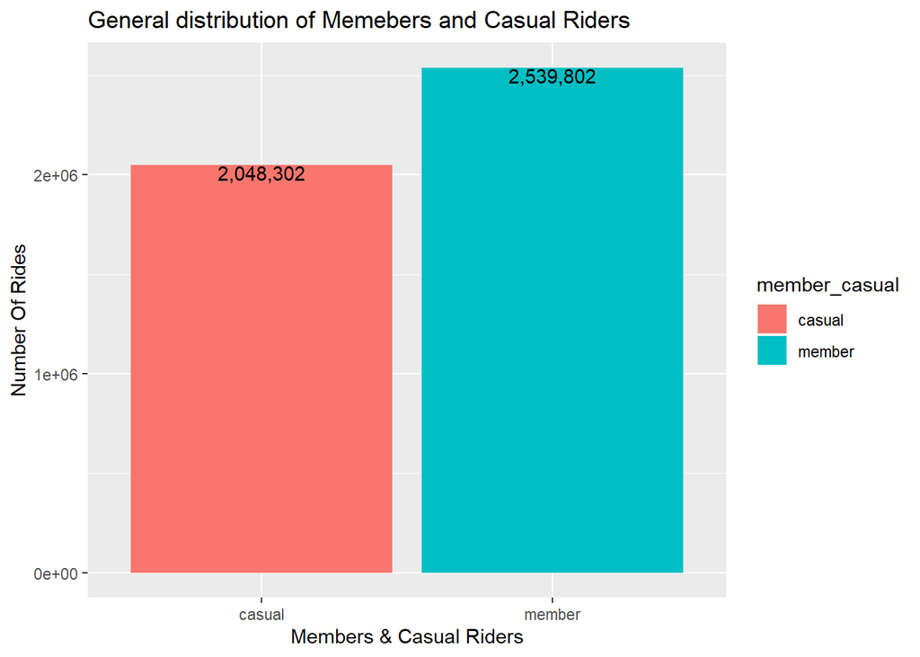

```r
df_clean %>%
  group_by(member_casual) %>%
  summarise(number_of_rides = n()) %>%
  ggplot(aes(x = member_casual, y = number_of_rides,
             fill = member_casual)) +
  geom_bar(stat = "identity") +
  geom_text(aes(label = dollar_format(prefix = "")(number_of_rides)), vjust = 1) +
  labs(x="Members & Casual Riders", y="Number Of Rides", title= "General distribution of Memebers and Casual Riders")
```

- In general, members’ trips are more than casual riders’ ones.

### Trips Percentages of Members & Casual Riders

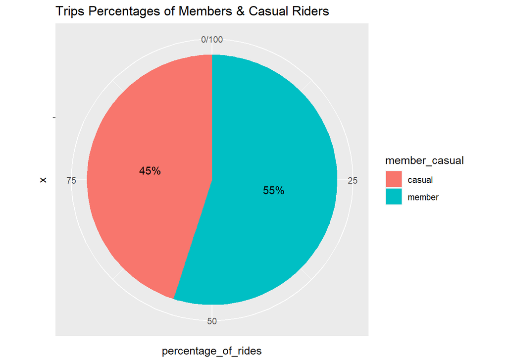

```r
df_clean %>%
  group_by(member_casual) %>%
  summarise(number_of_rides=length(ride_id),
            percentage_of_rides = round(100 * length(ride_id) / dim(df_clean)[1])) %>%
  ggplot(aes(x = "", y = percentage_of_rides, fill = member_casual)) +
  geom_bar(stat = "identity", width = 1) +
  coord_polar(theta = "y") +
  geom_text(aes(label = paste0(round(percentage_of_rides), "%")),
            position = position_stack(vjust = 0.5)) +
  labs(title = "Trips Percentages of Members & Casual Riders")
```

* With precise calculation, the percentage of members’ trips is more than casual riders’ trips ten percent (55% - 45% = 10%)

### Trips by Members and Casual Riders vs Months

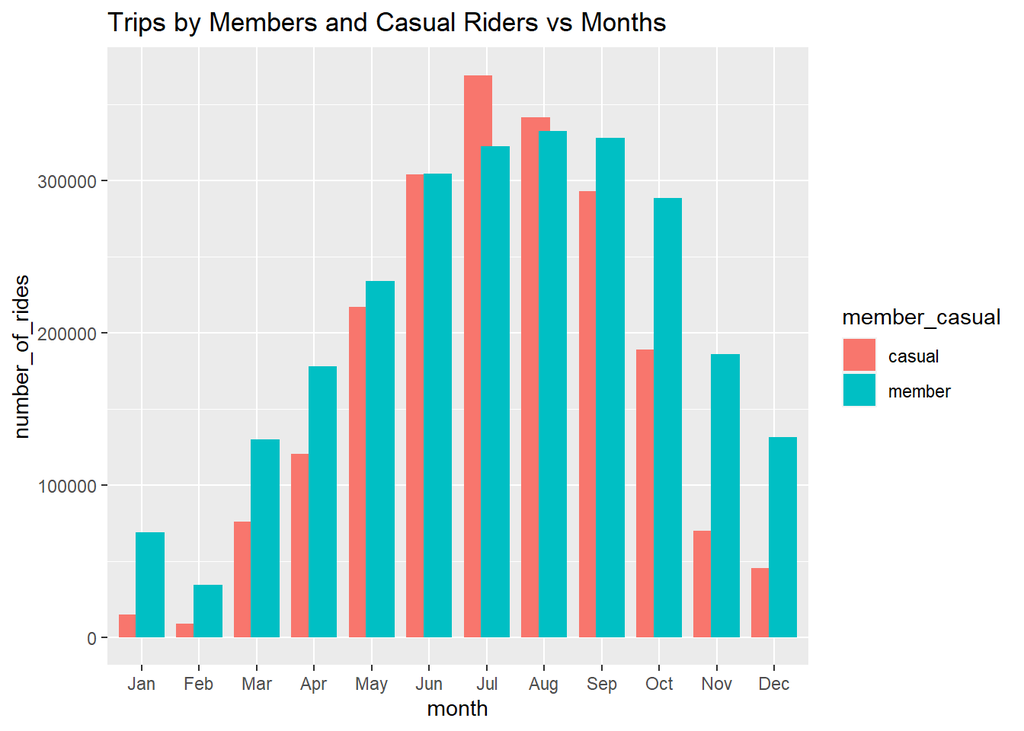

```r
df_clean %>%
  group_by(member_casual, month) %>%
  summarise(number_of_rides = n(), .groups="drop") %>%
  arrange(member_casual, month)  %>%
  ggplot(aes(x = month, y = number_of_rides, fill = member_casual)) +
  labs(title ="Trips by Members and Casual Riders vs Months") +
  geom_col(width=1, position = position_dodge(width=0.6)) +
  scale_y_continuous(labels = function(x) format(x, scientific = FALSE))
```

### Trips by Members and Casual Riders vs Days of week

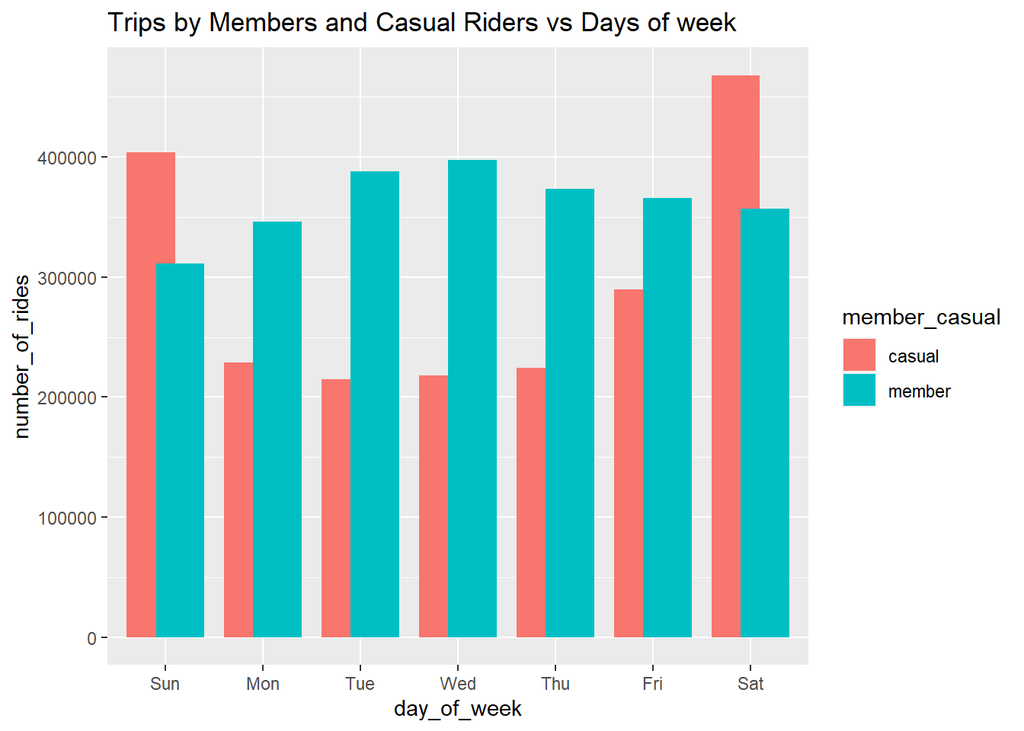

```r
df_clean %>%
  group_by(member_casual, day_of_week) %>%
  summarise(number_of_rides = n(), .groups="drop") %>%
  arrange(member_casual, day_of_week)  %>%
  ggplot(aes(x = day_of_week, y = number_of_rides, fill = member_casual)) +
  labs(title ="Trips by Members and Casual Riders vs Days of week") +
  geom_col(width=1, position = position_dodge(width=0.6)) +
  scale_y_continuous(labels = function(x) format(x, scientific = FALSE))
```

- From Monday to Friday, members have more trips than casual riders and vice versa casual riders have more trips than members on other days. Maybe members are residents or workers in this place and casual riders are almost travelers.
- We can check if our data depends on weekends and weekdays.

### Trips between Members & Casual Riders vs Weekdays & Weekends

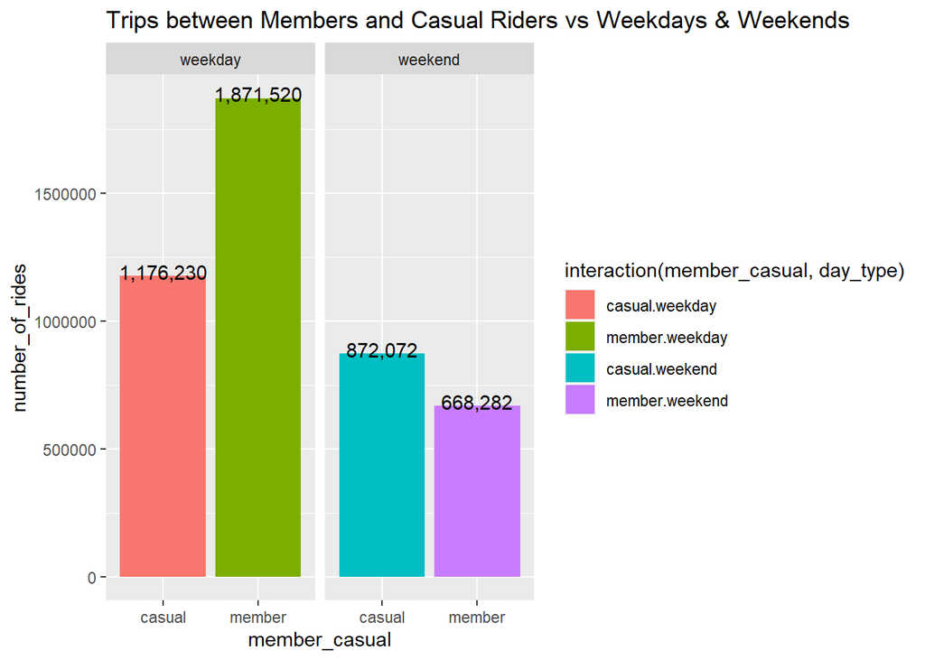

```r
df_clean %>%
  group_by(day_type, member_casual) %>%
  summarise(number_of_rides = n(), .groups="drop") %>%
  arrange(day_type, member_casual) %>%
  ggplot(aes(x = member_casual, y = number_of_rides,
             fill = interaction(member_casual, day_type))) +
  geom_bar(stat = "identity") +
  geom_text(aes(label = dollar_format(prefix = "")(number_of_rides)),
            vjust = 0.2) +
  facet_wrap(~ day_type) +
  labs(title="Trips between Members and Casual Riders vs Weekdays & Weekends")
```

- This plot clearly shows the distinct differences between the trips of members and casual riders versus weekdays and weekends.
- *This chart generates the idea of weekend-membership.*

### Trips by hours

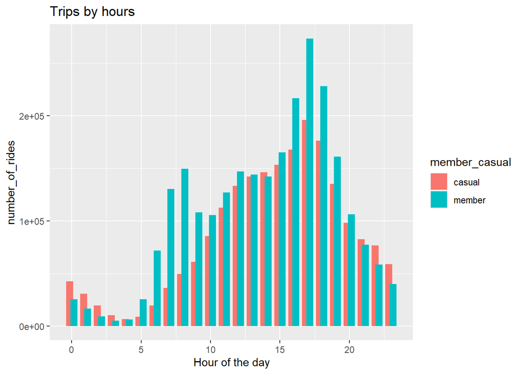

```r
df_clean %>%
  group_by(start_hour, member_casual) %>%
  summarise(number_of_rides = n(), .groups="drop") %>%
  arrange(start_hour, member_casual) %>%
  ggplot(aes(x=start_hour, y=number_of_rides, fill= member_casual)) +
  labs(x="Hour of the day", title="Trips by hours") +
  geom_col(width=1, position = position_dodge(width=0.6))
```

```r
  # geom_bar(stat = "identity")
  # facet_wrap(~ day_of_week)
```

### Trips between Members and Casual Riders vs Rideable Types

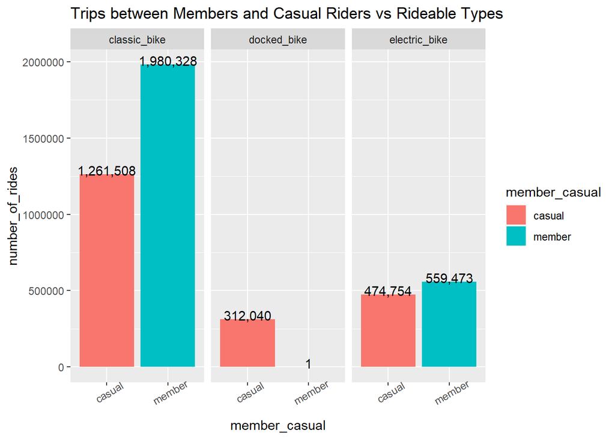

```r
df_clean %>%
  group_by(member_casual, rideable_type) %>%
  summarise(number_of_rides = n(), .groups="drop") %>%
  ggplot(aes(x = member_casual, y = number_of_rides,
             fill = member_casual)) +
  geom_bar(stat = "identity") +
  geom_text(aes(label = dollar_format(prefix = "")(number_of_rides)),
            vjust = 0.1) +
  theme(axis.text.x = element_text(angle = 30)) +
  labs(title="Trips between Members and Casual Riders vs Rideable Types") +
  facet_wrap(~rideable_type)
```

- The most preferred type is the classic bike.
- The docked bike is used by only casual riders.
- Both members and casual riders use the electric bike, but not much.

#### Trips between Members and Casual Riders vs Quarters

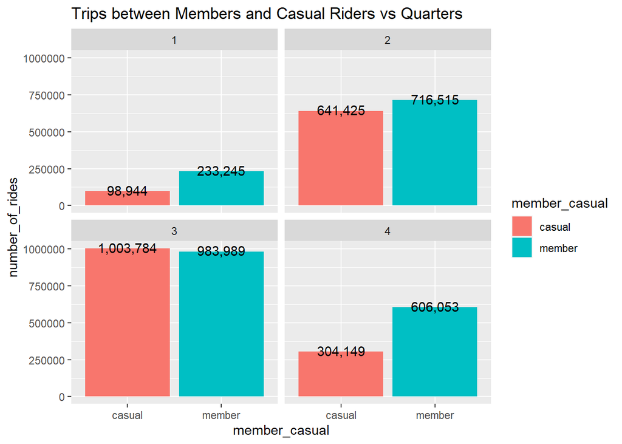

```r
df_clean %>%
  group_by(member_casual, quarter) %>%
  summarise(number_of_rides = n(), .groups="drop") %>%
  ggplot(aes(x = member_casual, y = number_of_rides,
             fill = member_casual)) +
  geom_bar(stat = "identity") +
  geom_text(aes(label = dollar_format(prefix = "")(number_of_rides)),
            vjust = 0.4) +
  # theme(axis.text.x = element_text(angle = 30)) +
  labs(title="Trips between Members and Casual Riders vs Quarters") +
  facet_wrap(~ quarter)
```

- *In quarter 2 and quarter 3, the trips of Casual Riders increase, we can think of season-membership*

## Average ride time

### Average ride time by Riders vs Day of the week

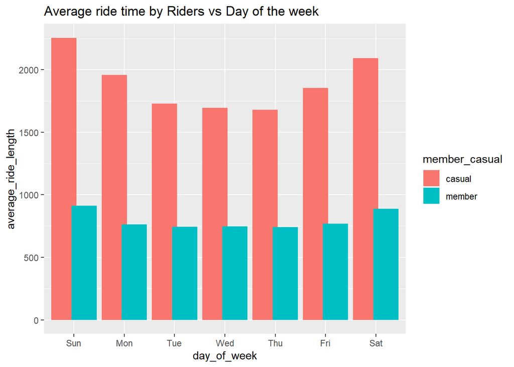

```r
df_clean %>%
  group_by(member_casual, day_of_week) %>%
  summarise(average_ride_length = mean(ride_length),
            .groups="drop") %>%
  ggplot(aes(x = day_of_week, y = average_ride_length,
             fill = member_casual)) +
  geom_col(width=1, position = position_dodge(width=0.8)) +
  labs(title ="Average ride time by Riders vs Day of the week")
```

### Average Ride Time by Riders vs Months

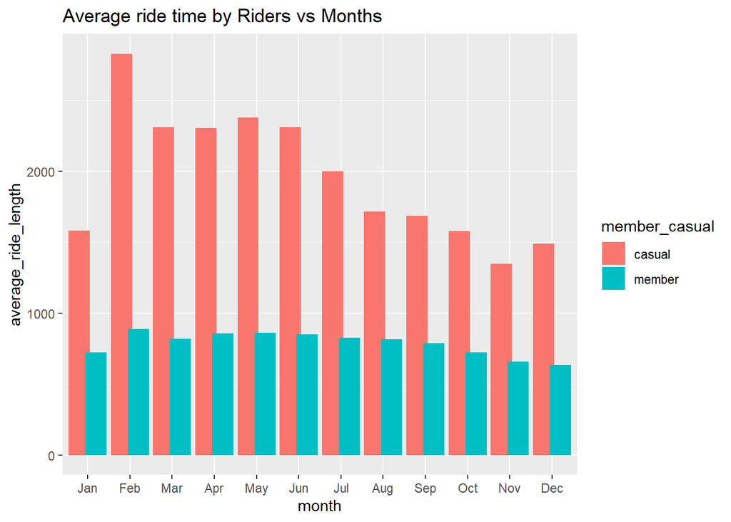

```r
df_clean %>%
  group_by(member_casual, month) %>%
  summarise(average_ride_length = mean(ride_length),
            .groups="drop") %>%
  ggplot(aes(x = month, y = average_ride_length,
             fill = member_casual)) +
  geom_col(width=1, position = position_dodge(width=0.8)) +
  labs(title ="Average ride time by Riders vs Months")
```

### Average ride time by Riders.

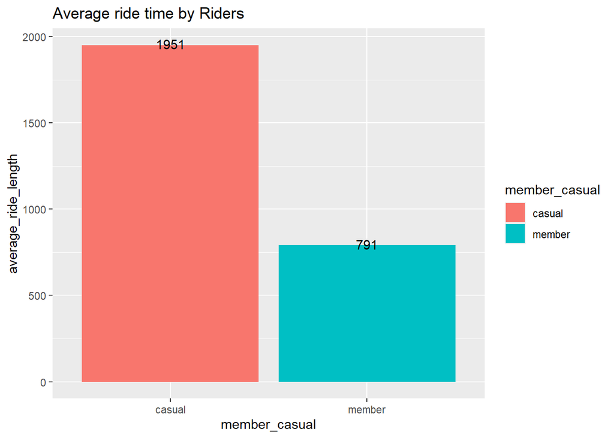

```r
df_clean %>%
  group_by(member_casual) %>%
  summarise(average_ride_length = mean(ride_length),
            .groups="drop") %>%
  ggplot(aes(x = member_casual, y = average_ride_length,
             fill = member_casual)) +
  geom_bar(stat = "identity") +
  geom_text(aes(label = round(average_ride_length)),
            vjust = 0.4) +
  # geom_col(width=0.5, position = position_dodge(width=0.5)) +
  labs(title ="Average ride time by Riders")
```

- **The three above plots show that the average ride time of casual riders is always more than members.**

#### Check the uniqeness of attribute ride_id

```r
if_else(length(unique(df_clean$ride_id)) == dim(df_clean)[1],
        "Ride id is unique",
        "Ride id is not unique")
```

```
## [1] "Ride id is unique"
```

- *All ride ids are unique so more rider data needed for further analysis to get more effective results.*

# Conclusions

## Findings

##### There are many differences in behavior and patterns of using services between Members and Casual Riders.

- Members use the service for shorter periods of time compared to casual riders.
- Casual Riders are impacted more by season, month, day of a week, and hour of a day.
- Patterns in hourly rides suggest that Member rides follow the peaks of a work day while almost Casual rides start the service in the afternoon.
- Our analysis shows that Members are workers or residents in Chicago while Casual Riders are most likely visitors of the city (this finding is more dependent on details of demographic data).

## Suggestion

- **Besides the full annual membership, we offer various types of membership, such as quarter-membership, month-membership, season-membership, weekend-membership and hours-membership with different prices.**
- **Various coupons and numerous discounts would be gifted along with the correspondent subscription membership for casual riders**
- **Generate various marketing campaigns, such as emails, or advertisements on the Internet or in the docking stations explaining the numerous benefits of membership. Campaigns should be placed at a suitable time for each type of membership.**

## Additonal data that could expand scope of analysis

- Pricing details for members and casual riders have more effect on our analysis.
- Address, Location, and Neighborhood details of riders may help our effective policy of membership.
- The residency status of the rider types is limited which affects our analysis result. Try to add more information about this.
- Take a survey of the general demographic information (career, age, sex, location, economic, etc.) of member to target the casual riders that have the similar demographic but are not members.

# Resources

- [Posit Docs](https://docs.posit.co/)
- [R for Data Science (2e)](https://r4ds.hadley.nz/)
- [R manuals](https://cran.r-project.org/manuals.html)
- [Statology R-Guides](https://www.statology.org/r-guides/)
- **RStudio Help in RStudio app**